# 170918_ex1

Cyril Statzer, ETH Zürich

9/18/2017

## Sampling from a log-normal distribution

In this experiment, we sample 100 values from a log-normal distribution. The distribution we choose here as a mean of 1 (µ = 1) and a standard deviation of 0.25 (σ = 0.25).

```r
sample <- rlnorm(100, meanlog = 1, sdlog = 0.25)
```

## Sampling from log-normal distribution

The sampled data is displayed as is in the histogram below. Sampling 100 observations from a log-normal distribution with a mean of 1 (µ = 1) and a standard deviation of 0.25 (σ = 0.25) yielded a new distribution. The distribution of the samples has a mean of µ = 2.66 and a standard deviation of σ = 0.688.

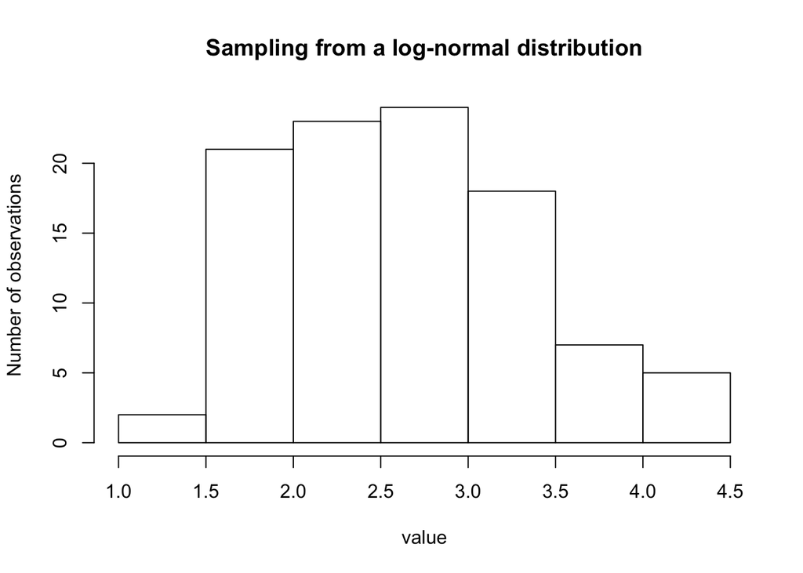

```r
hist(sample,10,main = "Sampling from a log-normal distribution", xlab = "value", ylab = "Number of observations")
```

## Sampling from log-normal distribution followed by log-transformation

Sampling 100 observations from a log-normal distribution with a mean of 1 (µ = 1) and a standard deviation of 0.25 yielded a new distribution. The distribution of the samples after log-transformation has a mean of µ = 0.947 and a standard deviation σ = 0.262.

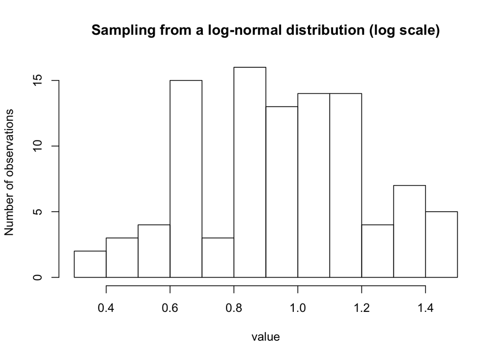

```r
hist(log(sample),10,main = "Sampling from a log-normal distribution (log scale)", xlab = "value", ylab = "Number of observations")
```

## Interpretation of results

When log transformation was applied to the sampled data the observed distribution is very similar to parent distribution. This can be observed for the mean (parent distribution: $\sf{µ_{parent}}$ = 1.00, sampled: $\sf{µ_{sampled}}$ = 0.947) and the standard deviation (parent distribution: $\sf{σ_{parent}}$ = 0.25, sampled: $\sf{σ_{sampled}}$ = 0.262)